# This is experiment one in the springer 1 to 3 numbering (originaly called e2)

Matt Green

```
## ......
## n.removed = 236
## percent.removed = 3.074117
```

# Analysis including 6:15:24

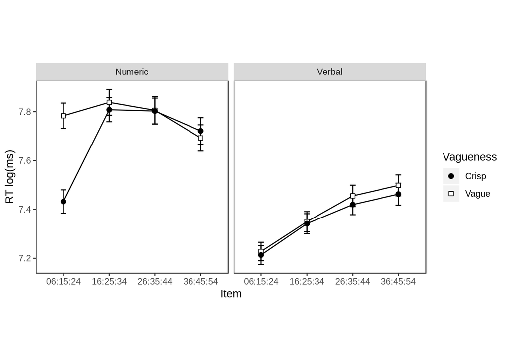

Original full model

rtFullModel

| term | 𝛽 | s.e. | d.f. | 𝑡 | 𝑝 | Pr(>\|t\|) | sig. |
| --- | --- | --- | --- | --- | --- | --- | --- |
| c_Vag | 0.058 | 0.013 | 28.99 | 4.55 | 8.87e-05 | <0.001 | ＊＊＊ |
| c_Num | 0.365 | 0.072 | 29.00 | 5.08 | 2.03e-05 | <0.001 | ＊＊＊ |
| c_Itm | 0.120 | 0.017 | 28.98 | 7.11 | 8.12e-08 | <0.001 | ＊＊＊ |
| c_Vag:c_Num | 0.069 | 0.027 | 29.04 | 2.53 | 1.69e-02 | <0.05 | ＊ |

The reviewer wants us to re-run this analysis without 6:15:24 but just removing that level results in a model that doesn’t converge. I had to drop c_Vag * c_Itm and c_Itm slopes over subjects to get it to converge.

rtFullModelMinus 6:15:24

| term | 𝛽 | s.e. | d.f. | 𝑡 | 𝑝 | Pr(>\|t\|) | sig. |
| --- | --- | --- | --- | --- | --- | --- | --- |
| c_Vag | 0.015 | 0.013 | 186.49 | 1.18 | 2.40e-01 | 0.24 |  |
| c_Num | 0.359 | 0.076 | 29.00 | 4.70 | 5.80e-05 | <0.001 | ＊＊＊ |
| c_Itm | 0.023 | 0.023 | 5493.08 | 0.99 | 3.23e-01 | 0.323 |  |
| c_Vag:c_Num | -0.022 | 0.025 | 5493.11 | -0.89 | 3.74e-01 | 0.374 |  |

So, after dropping the 6:15:24 level, there is still a disadvantage for Vagueness, but it is not significant (p=.24). There is still a significant disadvantage for Numeric instruction format (p<.001). There is still a disadvantage for increasing the number of dots but it is not significant (p=.323). The interaction between Vagueness and Instruction format changes sign, and is now non-significant (beta=-.022, p=.374).

However the full model and the reduced model are not really equivalent because the terms are different in order for the reduced model to converge. What we really want is a full model structure that converges with and without the 6:15:24 item.

If we use the structure of the reduced model for the structure of the full model we get this for the full model:

rtFullModel2

| term | 𝛽 | s.e. | d.f. | 𝑡 | 𝑝 | Pr(>\|t\|) | sig. |
| --- | --- | --- | --- | --- | --- | --- | --- |
| c_Vag | 0.058 | 0.0127 | 29.03 | 4.58 | 8.21e-05 | <0.001 | ＊＊＊ |
| c_Num | 0.364 | 0.0716 | 29.00 | 5.09 | 1.98e-05 | <0.001 | ＊＊＊ |
| c_Itm | 0.120 | 0.0097 | 7350.48 | 12.36 | 9.30e-35 | <0.001 | ＊＊＊ |
| c_Vag:c_Num | 0.068 | 0.0218 | 7351.60 | 3.14 | 1.70e-03 | <0.01 | ＊＊ |

and this for the reduced model:

```r
pretty_coef_table(rtFullModelMinus, "rtFullModelMinus 6:15:24")
```

rtFullModelMinus 6:15:24

| term | 𝛽 | s.e. | d.f. | 𝑡 | 𝑝 | Pr(>\|t\|) | sig. |
| --- | --- | --- | --- | --- | --- | --- | --- |
| c_Vag | 0.015 | 0.013 | 186.49 | 1.18 | 2.40e-01 | 0.24 |  |
| c_Num | 0.359 | 0.076 | 29.00 | 4.70 | 5.80e-05 | <0.001 | ＊＊＊ |
| c_Itm | 0.023 | 0.023 | 5493.08 | 0.99 | 3.23e-01 | 0.323 |  |
| c_Vag:c_Num | -0.022 | 0.025 | 5493.11 | -0.89 | 3.74e-01 | 0.374 |  |

fullmodel with Helmert contrasts on Item

c_Vag * c_Num + Item + (1 + c_Vag + c_Num + Item | Subject)

| term | 𝛽 | s.e. | d.f. | 𝑡 | 𝑝 | Pr(>\|t\|) | sig. |
| --- | --- | --- | --- | --- | --- | --- | --- |
| c_Vag | 0.058 | 0.0129 | 30.89 | 4.50 | 8.89e-05 | <0.001 | ＊＊＊ |
| c_Num | 0.365 | 0.0718 | 29.00 | 5.09 | 2.00e-05 | <0.001 | ＊＊＊ |
| Item1 | 0.086 | 0.0131 | 31.47 | 6.58 | 2.22e-07 | <0.001 | ＊＊＊ |
| Item2 | 0.042 | 0.0075 | 32.10 | 5.55 | 3.91e-06 | <0.001 | ＊＊＊ |
| Item3 | 0.015 | 0.0035 | 53.44 | 4.12 | 1.33e-04 | <0.001 | ＊＊＊ |
| c_Vag:c_Num | 0.069 | 0.0215 | 7321.11 | 3.20 | 1.39e-03 | <0.01 | ＊＊ |

reducedmodel with Helmert contrasts on Item

c_Vag * c_Num + Item + (1 + c_Vag + c_Num + Item | Subject)

| term | 𝛽 | s.e. | d.f. | 𝑡 | 𝑝 | Pr(>\|t\|) | sig. |
| --- | --- | --- | --- | --- | --- | --- | --- |
| c_Vag | 0.0156 | 0.0130 | 190.73 | 1.19 | 2.35e-01 | 0.235 |  |
| c_Num | 0.3594 | 0.0764 | 29.00 | 4.71 | 5.74e-05 | <0.001 | ＊＊＊ |
| Item1 | 0.0198 | 0.0086 | 81.69 | 2.31 | 2.33e-02 | <0.05 | ＊ |
| Item2 | -0.0016 | 0.0050 | 76.99 | -0.33 | 7.42e-01 | 0.742 |  |
| c_Vag:c_Num | -0.0221 | 0.0251 | 5492.11 | -0.88 | 3.78e-01 | 0.378 |  |

However the plot of means suggests that the main variables are c_Num and Item so it might be better to have a model structure that includes a c_Num*Item term.

```r
dat_model <- dat
dat_model$c_Vag <- ifelse(dat_model$Vagueness=="Crisp", -0.5, 0.5)
dat_model$c_Num <- ifelse(dat_model$Number=="Verbal", -0.5, 0.5)
contrasts(dat_model$Item) <- contr.helmert(4)
myMod1 <- lmerTest::lmer(1 + RT_log ~ c_Vag + c_Num + Item + c_Num:Item +(1|Subject), dat_model)
pretty_coef_table(myMod1, "myMod1")
```

myMod1

| term | 𝛽 | s.e. | d.f. | 𝑡 | 𝑝 | Pr(>\|t\|) | sig. |
| --- | --- | --- | --- | --- | --- | --- | --- |
| c_Vag | 0.056 | 0.0117 | 7403.02 | 4.83 | 1.38e-06 | <0.001 | ＊＊＊ |
| c_Num | 0.363 | 0.0117 | 7403.02 | 31.14 | 3.82e-200 | <0.001 | ＊＊＊ |
| Item1 | 0.086 | 0.0082 | 7403.01 | 10.43 | 2.61e-25 | <0.001 | ＊＊＊ |
| Item2 | 0.041 | 0.0048 | 7403.03 | 8.54 | 1.61e-17 | <0.001 | ＊＊＊ |
| Item3 | 0.014 | 0.0034 | 7403.01 | 4.00 | 6.40e-05 | <0.001 | ＊＊＊ |
| c_Num:Item1 | 0.047 | 0.0165 | 7403.01 | 2.83 | 4.68e-03 | <0.01 | ＊＊ |
| c_Num:Item2 | -0.021 | 0.0095 | 7403.03 | -2.25 | 2.48e-02 | <0.05 | ＊ |
| c_Num:Item3 | -0.046 | 0.0068 | 7403.01 | -6.79 | 1.25e-11 | <0.001 | ＊＊＊ |

```r
dat_model <- droplevels(subset(dat, Item!="06:15:24"))
dat_model$c_Vag <- ifelse(dat_model$Vagueness=="Crisp", -0.5, 0.5)
dat_model$c_Num <- ifelse(dat_model$Number=="Verbal", -0.5, 0.5)
contrasts(dat_model$Item) <- contr.helmert(3)
myMod2 <- lmerTest::lmer(1 + RT_log ~ c_Vag + c_Num + Item + c_Num:Item +(1|Subject), dat_model)
pretty_coef_table(myMod2, "myMod2:no6:15:24")
```

myMod2:no6:15:24

| term | 𝛽 | s.e. | d.f. | 𝑡 | 𝑝 | Pr(>\|t\|) | sig. |
| --- | --- | --- | --- | --- | --- | --- | --- |
| c_Vag | 0.014 | 0.0136 | 5520.02 | 1.06 | 2.90e-01 | 0.29 |  |
| c_Num | 0.357 | 0.0136 | 5520.03 | 26.20 | 1.02e-142 | <0.001 | ＊＊＊ |
| Item1 | 0.019 | 0.0083 | 5520.03 | 2.22 | 2.63e-02 | <0.05 | ＊ |
| Item2 | -0.003 | 0.0048 | 5520.01 | -0.62 | 5.36e-01 | 0.536 |  |
| c_Num:Item1 | -0.055 | 0.0167 | 5520.03 | -3.29 | 1.01e-03 | <0.01 | ＊＊ |
| c_Num:Item2 | -0.065 | 0.0096 | 5520.01 | -6.75 | 1.59e-11 | <0.001 | ＊＊＊ |